# Practice with pandas

- import the covid19-healthy-diet-dataset: it contains some stats related to covid19 and diet for each country.
- add domain information: create a new column with the continent (plenty of python libraries out there)
- use pandas and plotting utilities to explore the data, e.g.:
  - Which continents have the highest ratio reported for Covid19 deaths?
  - Which is the state with the highest rate of death?
  - Compare the distribution of Deaths rates among European and North American countries.

The notebook contains some example analyses, merely for practicing with Pandas: it is not to be considered complete and exhaustive.

```python
from matplotlib import pyplot as plt
import os
import pandas as pd
```

```python
df = pd.read_csv(os.path.join('dataset','healthCovid19.csv'),index_col = 0)
```

```python
df
```

| Country | Alcoholic Beverages | Animal Products | Animal fats | Aquatic Products, Other | Cereals - Excluding Beer | Eggs | Fish, Seafood | Fruits - Excluding Wine | Meat | Miscellaneous | ... | Vegetable Oils | Vegetables | Obesity | Undernourished | Confirmed | Deaths | Recovered | Active | Population | Unit (all except Population) |
| --- | --- | --- | --- | --- | --- | --- | --- | --- | --- | --- | --- | --- | --- | --- | --- | --- | --- | --- | --- | --- | --- |
| Afghanistan | 0.0000 | 21.6397 | 6.2224 | 0.0 | 8.0353 | 0.6859 | 0.0327 | 0.4246 | 6.1244 | 0.0163 | ... | 17.0831 | 0.3593 | 4.5 | 29.8 | 0.142134 | 0.006186 | 0.123374 | 0.012574 | 38928000.0 | % |
| Albania | 0.0000 | 32.0002 | 3.4172 | 0.0 | 2.6734 | 1.6448 | 0.1445 | 0.6418 | 8.7428 | 0.0170 | ... | 9.2443 | 0.6503 | 22.3 | 6.2 | 2.967301 | 0.050951 | 1.792636 | 1.123714 | 2838000.0 | % |
| Algeria | 0.0000 | 14.4175 | 0.8972 | 0.0 | 4.2035 | 1.2171 | 0.2008 | 0.5772 | 3.8961 | 0.0439 | ... | 27.3606 | 0.5145 | 26.6 | 3.9 | 0.244897 | 0.006558 | 0.167572 | 0.070767 | 44357000.0 | % |
| Angola | 0.0000 | 15.3041 | 1.3130 | 0.0 | 6.5545 | 0.1539 | 1.4155 | 0.3488 | 11.0268 | 0.0308 | ... | 22.4638 | 0.1231 | 6.8 | 25 | 0.061687 | 0.001461 | 0.056808 | 0.003419 | 32522000.0 | % |
| Antigua and Barbuda | 0.0000 | 27.7033 | 4.6686 | 0.0 | 3.2153 | 0.3872 | 1.5263 | 1.2177 | 14.3202 | 0.0898 | ... | 14.4436 | 0.2469 | 19.1 | NaN | 0.293878 | 0.007143 | 0.190816 | 0.095918 | 98000.0 | % |
| ... | ... | ... | ... | ... | ... | ... | ... | ... | ... | ... | ... | ... | ... | ... | ... | ... | ... | ... | ... | ... | ... |
| Venezuela (Bolivarian Republic of) | 0.0000 | 16.3261 | 2.2673 | 0.0 | 2.5449 | 0.6555 | 0.5707 | 0.9640 | 7.0949 | 0.0077 | ... | 29.5211 | 0.1851 | 25.2 | 21.2 | 0.452585 | 0.004287 | 0.424399 | 0.023899 | 28645000.0 | % |
| Vietnam | 0.0000 | 33.2484 | 3.8238 | 0.0 | 3.7155 | 0.7839 | 1.1217 | 0.4079 | 26.4292 | 0.0064 | ... | 5.6211 | 0.6373 | 2.1 | 9.3 | 0.002063 | 0.000036 | 0.001526 | 0.000501 | 96209000.0 | % |
| Yemen | 0.0000 | 12.5401 | 2.0131 | 0.0 | 11.5271 | 0.5514 | 0.3847 | 0.2564 | 8.0010 | 0.0256 | ... | 23.6312 | 0.1667 | 14.1 | 38.9 | 0.007131 | 0.002062 | 0.004788 | 0.000282 | 29826000.0 | % |
| Zambia | 0.0783 | 9.6005 | 1.6113 | 0.0 | 14.3225 | 0.6266 | 1.0070 | 0.1343 | 4.9010 | 0.0224 | ... | 15.2848 | 0.1567 | 6.5 | 46.7 | 0.334133 | 0.004564 | 0.290524 | 0.039045 | 18384000.0 | % |
| Zimbabwe | 0.0000 | 10.3796 | 2.9543 | 0.0 | 9.7922 | 0.3682 | 0.2455 | 0.0614 | 4.5674 | 0.0175 | ... | 26.9396 | 0.0789 | 12.3 | 51.3 | 0.232033 | 0.008854 | 0.190964 | 0.032214 | 14863000.0 | % |

170 rows × 31 columns

Let's add domain information: create a new column with the continent

```python
#! pip install pycountry
import pycountry_convert as pc

# will raise an error, if the country name is not found in the library look-up table

# df['Country_Code'] = df.index.to_series().apply(
#     lambda x: pc.country_name_to_country_alpha2(x, cn_name_format="default"))
```

```python
import pycountry_convert as pc

def to_code(country):
    try:
        country_code = pc.country_name_to_country_alpha2(country, cn_name_format="default")
    except KeyError:
        print(country)
        country_code = None
    return country_code

def to_continent(code):
    try:
        continent_name = pc.country_alpha2_to_continent_code(code)
    except KeyError:
        continent_name = None
    return continent_name
```

```python
df['Country_Code'] = df.index.to_series().apply(lambda x: to_code(x))
df['Continent'] = df['Country_Code'].apply(lambda x: to_continent(x))
```

```
Cote d'Ivoire
Iran (Islamic Republic of)
Korea, North
Korea, South
Taiwan*
Venezuela (Bolivarian Republic of)
```

```python
df
```

| Country | Alcoholic Beverages | Animal Products | Animal fats | Aquatic Products, Other | Cereals - Excluding Beer | Eggs | Fish, Seafood | Fruits - Excluding Wine | Meat | Miscellaneous | ... | Obesity | Undernourished | Confirmed | Deaths | Recovered | Active | Population | Unit (all except Population) | Country_Code | Continent |
| --- | --- | --- | --- | --- | --- | --- | --- | --- | --- | --- | --- | --- | --- | --- | --- | --- | --- | --- | --- | --- | --- |
| Afghanistan | 0.0000 | 21.6397 | 6.2224 | 0.0 | 8.0353 | 0.6859 | 0.0327 | 0.4246 | 6.1244 | 0.0163 | ... | 4.5 | 29.8 | 0.142134 | 0.006186 | 0.123374 | 0.012574 | 38928000.0 | % | AF | AS |
| Albania | 0.0000 | 32.0002 | 3.4172 | 0.0 | 2.6734 | 1.6448 | 0.1445 | 0.6418 | 8.7428 | 0.0170 | ... | 22.3 | 6.2 | 2.967301 | 0.050951 | 1.792636 | 1.123714 | 2838000.0 | % | AL | EU |
| Algeria | 0.0000 | 14.4175 | 0.8972 | 0.0 | 4.2035 | 1.2171 | 0.2008 | 0.5772 | 3.8961 | 0.0439 | ... | 26.6 | 3.9 | 0.244897 | 0.006558 | 0.167572 | 0.070767 | 44357000.0 | % | DZ | AF |
| Angola | 0.0000 | 15.3041 | 1.3130 | 0.0 | 6.5545 | 0.1539 | 1.4155 | 0.3488 | 11.0268 | 0.0308 | ... | 6.8 | 25 | 0.061687 | 0.001461 | 0.056808 | 0.003419 | 32522000.0 | % | AO | AF |
| Antigua and Barbuda | 0.0000 | 27.7033 | 4.6686 | 0.0 | 3.2153 | 0.3872 | 1.5263 | 1.2177 | 14.3202 | 0.0898 | ... | 19.1 | NaN | 0.293878 | 0.007143 | 0.190816 | 0.095918 | 98000.0 | % | AG | NA |
| ... | ... | ... | ... | ... | ... | ... | ... | ... | ... | ... | ... | ... | ... | ... | ... | ... | ... | ... | ... | ... | ... |
| Venezuela (Bolivarian Republic of) | 0.0000 | 16.3261 | 2.2673 | 0.0 | 2.5449 | 0.6555 | 0.5707 | 0.9640 | 7.0949 | 0.0077 | ... | 25.2 | 21.2 | 0.452585 | 0.004287 | 0.424399 | 0.023899 | 28645000.0 | % | None | None |
| Vietnam | 0.0000 | 33.2484 | 3.8238 | 0.0 | 3.7155 | 0.7839 | 1.1217 | 0.4079 | 26.4292 | 0.0064 | ... | 2.1 | 9.3 | 0.002063 | 0.000036 | 0.001526 | 0.000501 | 96209000.0 | % | VN | AS |
| Yemen | 0.0000 | 12.5401 | 2.0131 | 0.0 | 11.5271 | 0.5514 | 0.3847 | 0.2564 | 8.0010 | 0.0256 | ... | 14.1 | 38.9 | 0.007131 | 0.002062 | 0.004788 | 0.000282 | 29826000.0 | % | YE | AS |
| Zambia | 0.0783 | 9.6005 | 1.6113 | 0.0 | 14.3225 | 0.6266 | 1.0070 | 0.1343 | 4.9010 | 0.0224 | ... | 6.5 | 46.7 | 0.334133 | 0.004564 | 0.290524 | 0.039045 | 18384000.0 | % | ZM | AF |
| Zimbabwe | 0.0000 | 10.3796 | 2.9543 | 0.0 | 9.7922 | 0.3682 | 0.2455 | 0.0614 | 4.5674 | 0.0175 | ... | 12.3 | 51.3 | 0.232033 | 0.008854 | 0.190964 | 0.032214 | 14863000.0 | % | ZW | AF |

170 rows × 33 columns

```python
df.isna().sum(axis = 0)
```

```
Alcoholic Beverages             0
Animal Products                 0
Animal fats                     0
Aquatic Products, Other         0
Cereals - Excluding Beer        0
Eggs                            0
Fish, Seafood                   0
Fruits - Excluding Wine         0
Meat                            0
Miscellaneous                   0
Milk - Excluding Butter         0
Offals                          0
Oilcrops                        0
Pulses                          0
Spices                          0
Starchy Roots                   0
Stimulants                      0
Sugar Crops                     0
Sugar & Sweeteners              0
Treenuts                        0
Vegetal Products                0
Vegetable Oils                  0
Vegetables                      0
Obesity                         3
Undernourished                  7
Confirmed                       6
Deaths                          6
Recovered                       6
Active                          8
Population                      0
Unit (all except Population)    0
Country_Code                    6
Continent                       7
dtype: int64
```

The code column can be safely deleted

```python
df = df.drop(columns = 'Country_Code',axis = 1)
```

```python
df
```

| Country | Alcoholic Beverages | Animal Products | Animal fats | Aquatic Products, Other | Cereals - Excluding Beer | Eggs | Fish, Seafood | Fruits - Excluding Wine | Meat | Miscellaneous | ... | Vegetables | Obesity | Undernourished | Confirmed | Deaths | Recovered | Active | Population | Unit (all except Population) | Continent |
| --- | --- | --- | --- | --- | --- | --- | --- | --- | --- | --- | --- | --- | --- | --- | --- | --- | --- | --- | --- | --- | --- |
| Afghanistan | 0.0000 | 21.6397 | 6.2224 | 0.0 | 8.0353 | 0.6859 | 0.0327 | 0.4246 | 6.1244 | 0.0163 | ... | 0.3593 | 4.5 | 29.8 | 0.142134 | 0.006186 | 0.123374 | 0.012574 | 38928000.0 | % | AS |
| Albania | 0.0000 | 32.0002 | 3.4172 | 0.0 | 2.6734 | 1.6448 | 0.1445 | 0.6418 | 8.7428 | 0.0170 | ... | 0.6503 | 22.3 | 6.2 | 2.967301 | 0.050951 | 1.792636 | 1.123714 | 2838000.0 | % | EU |
| Algeria | 0.0000 | 14.4175 | 0.8972 | 0.0 | 4.2035 | 1.2171 | 0.2008 | 0.5772 | 3.8961 | 0.0439 | ... | 0.5145 | 26.6 | 3.9 | 0.244897 | 0.006558 | 0.167572 | 0.070767 | 44357000.0 | % | AF |
| Angola | 0.0000 | 15.3041 | 1.3130 | 0.0 | 6.5545 | 0.1539 | 1.4155 | 0.3488 | 11.0268 | 0.0308 | ... | 0.1231 | 6.8 | 25 | 0.061687 | 0.001461 | 0.056808 | 0.003419 | 32522000.0 | % | AF |
| Antigua and Barbuda | 0.0000 | 27.7033 | 4.6686 | 0.0 | 3.2153 | 0.3872 | 1.5263 | 1.2177 | 14.3202 | 0.0898 | ... | 0.2469 | 19.1 | NaN | 0.293878 | 0.007143 | 0.190816 | 0.095918 | 98000.0 | % | NA |
| ... | ... | ... | ... | ... | ... | ... | ... | ... | ... | ... | ... | ... | ... | ... | ... | ... | ... | ... | ... | ... | ... |
| Venezuela (Bolivarian Republic of) | 0.0000 | 16.3261 | 2.2673 | 0.0 | 2.5449 | 0.6555 | 0.5707 | 0.9640 | 7.0949 | 0.0077 | ... | 0.1851 | 25.2 | 21.2 | 0.452585 | 0.004287 | 0.424399 | 0.023899 | 28645000.0 | % | None |
| Vietnam | 0.0000 | 33.2484 | 3.8238 | 0.0 | 3.7155 | 0.7839 | 1.1217 | 0.4079 | 26.4292 | 0.0064 | ... | 0.6373 | 2.1 | 9.3 | 0.002063 | 0.000036 | 0.001526 | 0.000501 | 96209000.0 | % | AS |
| Yemen | 0.0000 | 12.5401 | 2.0131 | 0.0 | 11.5271 | 0.5514 | 0.3847 | 0.2564 | 8.0010 | 0.0256 | ... | 0.1667 | 14.1 | 38.9 | 0.007131 | 0.002062 | 0.004788 | 0.000282 | 29826000.0 | % | AS |
| Zambia | 0.0783 | 9.6005 | 1.6113 | 0.0 | 14.3225 | 0.6266 | 1.0070 | 0.1343 | 4.9010 | 0.0224 | ... | 0.1567 | 6.5 | 46.7 | 0.334133 | 0.004564 | 0.290524 | 0.039045 | 18384000.0 | % | AF |
| Zimbabwe | 0.0000 | 10.3796 | 2.9543 | 0.0 | 9.7922 | 0.3682 | 0.2455 | 0.0614 | 4.5674 | 0.0175 | ... | 0.0789 | 12.3 | 51.3 | 0.232033 | 0.008854 | 0.190964 | 0.032214 | 14863000.0 | % | AF |

170 rows × 32 columns

Possibly, fill missing values

```python
df[df.Continent.isna()]
```

| Country | Alcoholic Beverages | Animal Products | Animal fats | Aquatic Products, Other | Cereals - Excluding Beer | Eggs | Fish, Seafood | Fruits - Excluding Wine | Meat | Miscellaneous | ... | Vegetables | Obesity | Undernourished | Confirmed | Deaths | Recovered | Active | Population | Unit (all except Population) | Continent |
| --- | --- | --- | --- | --- | --- | --- | --- | --- | --- | --- | --- | --- | --- | --- | --- | --- | --- | --- | --- | --- | --- |
| Cote d'Ivoire | 0.0000 | 5.3253 | 0.2726 | 0.0000 | 4.9709 | 0.4271 | 1.2268 | 0.5271 | 2.5809 | 0.0091 | ... | 0.3272 | 9.0 | 19 | 0.112959 | 0.000619 | 0.106105 | 0.006235 | 26175000.0 | % | None |
| Iran (Islamic Republic of) | 0.0000 | 16.9273 | 6.0372 | 0.0000 | 5.5867 | 1.3259 | 0.6114 | 0.6243 | 6.1724 | 0.0000 | ... | 0.5278 | 25.5 | 4.9 | 1.734248 | 0.069414 | 1.482322 | 0.182512 | 84150000.0 | % | None |
| Korea, North | 0.0000 | 11.4709 | 0.0262 | 0.0000 | 7.2234 | 1.6911 | 0.5375 | 0.6424 | 8.7179 | 0.0131 | ... | 1.0357 | 7.1 | 47.8 | NaN | NaN | NaN | NaN | 25779000.0 | % | None |
| Korea, South | 0.0976 | 20.0483 | 4.2523 | 0.0511 | 1.8403 | 1.3524 | 1.9147 | 0.1766 | 11.1860 | 0.0000 | ... | 0.6924 | 4.9 | <2.5 | 0.156227 | 0.002841 | 0.136855 | 0.016531 | 51781000.0 | % | None |
| Taiwan* | 0.0000 | 19.3217 | 2.6952 | 0.0000 | 1.1629 | 1.4818 | 0.4667 | 0.2956 | 13.2817 | 0.0194 | ... | 0.3111 | NaN | 3.5 | 0.003914 | 0.000038 | 0.003571 | 0.000305 | 23610000.0 | % | None |
| Timor-Leste | 0.0000 | 17.8988 | 2.0345 | 0.0000 | 10.2168 | 0.2446 | 0.7893 | 1.3007 | 14.5525 | 0.1112 | ... | 0.1668 | 2.9 | 24.9 | 0.006070 | 0.000000 | 0.004628 | 0.001442 | 1318000.0 | % | None |
| Venezuela (Bolivarian Republic of) | 0.0000 | 16.3261 | 2.2673 | 0.0000 | 2.5449 | 0.6555 | 0.5707 | 0.9640 | 7.0949 | 0.0077 | ... | 0.1851 | 25.2 | 21.2 | 0.452585 | 0.004287 | 0.424399 | 0.023899 | 28645000.0 | % | None |

7 rows × 32 columns

```python
df.loc["Cote d'Ivoire","Continent"] = "AF"
```

```python
df[df.Continent.isna()]
```

| Country | Alcoholic Beverages | Animal Products | Animal fats | Aquatic Products, Other | Cereals - Excluding Beer | Eggs | Fish, Seafood | Fruits - Excluding Wine | Meat | Miscellaneous | ... | Vegetables | Obesity | Undernourished | Confirmed | Deaths | Recovered | Active | Population | Unit (all except Population) | Continent |
| --- | --- | --- | --- | --- | --- | --- | --- | --- | --- | --- | --- | --- | --- | --- | --- | --- | --- | --- | --- | --- | --- |
| Iran (Islamic Republic of) | 0.0000 | 16.9273 | 6.0372 | 0.0000 | 5.5867 | 1.3259 | 0.6114 | 0.6243 | 6.1724 | 0.0000 | ... | 0.5278 | 25.5 | 4.9 | 1.734248 | 0.069414 | 1.482322 | 0.182512 | 84150000.0 | % | None |
| Korea, North | 0.0000 | 11.4709 | 0.0262 | 0.0000 | 7.2234 | 1.6911 | 0.5375 | 0.6424 | 8.7179 | 0.0131 | ... | 1.0357 | 7.1 | 47.8 | NaN | NaN | NaN | NaN | 25779000.0 | % | None |
| Korea, South | 0.0976 | 20.0483 | 4.2523 | 0.0511 | 1.8403 | 1.3524 | 1.9147 | 0.1766 | 11.1860 | 0.0000 | ... | 0.6924 | 4.9 | <2.5 | 0.156227 | 0.002841 | 0.136855 | 0.016531 | 51781000.0 | % | None |
| Taiwan* | 0.0000 | 19.3217 | 2.6952 | 0.0000 | 1.1629 | 1.4818 | 0.4667 | 0.2956 | 13.2817 | 0.0194 | ... | 0.3111 | NaN | 3.5 | 0.003914 | 0.000038 | 0.003571 | 0.000305 | 23610000.0 | % | None |
| Timor-Leste | 0.0000 | 17.8988 | 2.0345 | 0.0000 | 10.2168 | 0.2446 | 0.7893 | 1.3007 | 14.5525 | 0.1112 | ... | 0.1668 | 2.9 | 24.9 | 0.006070 | 0.000000 | 0.004628 | 0.001442 | 1318000.0 | % | None |
| Venezuela (Bolivarian Republic of) | 0.0000 | 16.3261 | 2.2673 | 0.0000 | 2.5449 | 0.6555 | 0.5707 | 0.9640 | 7.0949 | 0.0077 | ... | 0.1851 | 25.2 | 21.2 | 0.452585 | 0.004287 | 0.424399 | 0.023899 | 28645000.0 | % | None |

6 rows × 32 columns

Now we can look at aggregated information, grouping countries by continent.

```python
aggregated_df = df.groupby('Continent').mean()
aggregated_df
```

| Continent | Alcoholic Beverages | Animal Products | Animal fats | Aquatic Products, Other | Cereals - Excluding Beer | Eggs | Fish, Seafood | Fruits - Excluding Wine | Meat | Miscellaneous | ... | Treenuts | Vegetal Products | Vegetable Oils | Vegetables | Obesity | Confirmed | Deaths | Recovered | Active | Population |
| --- | --- | --- | --- | --- | --- | --- | --- | --- | --- | --- | --- | --- | --- | --- | --- | --- | --- | --- | --- | --- | --- |
| AF | 0.00174 | 12.512789 | 1.560627 | 0.000000 | 7.044578 | 0.374902 | 0.741191 | 0.626524 | 6.291544 | 0.042862 | ... | 0.477191 | 37.486764 | 22.368849 | 0.268884 | 10.515556 | 0.416921 | 0.008637 | 0.354711 | 0.053573 | 2.655202e+07 |
| AS | 0.00000 | 21.009695 | 3.516049 | 0.000416 | 4.521692 | 1.251749 | 1.142303 | 0.437286 | 9.557727 | 0.057189 | ... | 1.019300 | 28.990235 | 18.184395 | 0.428400 | 15.694595 | 1.689065 | 0.018701 | 1.471822 | 0.198542 | 1.187954e+08 |
| EU | 0.00000 | 28.212874 | 7.796749 | 0.000000 | 2.187867 | 1.249156 | 0.659305 | 0.330315 | 10.506649 | 0.038115 | ... | 0.896664 | 21.787821 | 15.682008 | 0.305085 | 24.748718 | 4.691415 | 0.094828 | 3.018687 | 1.577899 | 1.908444e+07 |
| NA | 0.00000 | 22.936843 | 4.453526 | 0.000278 | 3.888248 | 1.029904 | 0.796530 | 0.904252 | 11.449391 | 0.111943 | ... | 0.399783 | 27.063509 | 17.694361 | 0.226278 | 24.330435 | 1.679561 | 0.034794 | 1.059669 | 0.605062 | 2.545009e+07 |
| OC | 0.00000 | 20.727344 | 5.060189 | 0.000400 | 2.599167 | 0.609878 | 1.550778 | 0.340889 | 10.618300 | 0.098867 | ... | 0.543556 | 29.273267 | 12.574200 | 0.155911 | 32.500000 | 0.028081 | 0.000709 | 0.025768 | 0.001603 | 3.730333e+06 |
| SA | 0.00000 | 23.768045 | 3.077809 | 0.000000 | 2.998227 | 1.302809 | 0.552282 | 0.639545 | 13.418791 | 0.043000 | ... | 0.345682 | 26.230955 | 18.557136 | 0.294691 | 22.945455 | 2.691647 | 0.075820 | 2.400274 | 0.225210 | 3.638627e+07 |

6 rows × 29 columns

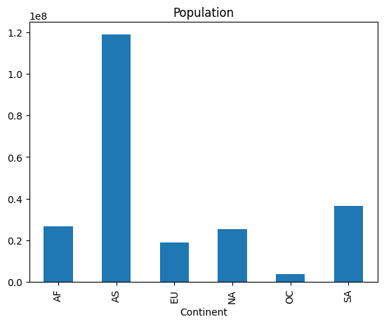

```python
aggregated_df['Population'].plot(kind = 'bar')
plt.title('Population')
```

Which continents have the highest ratio reported for Covid19 deaths?

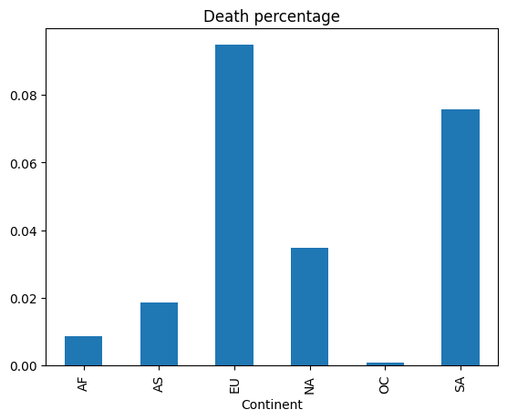

```python
aggregated_df['Deaths'].plot(kind = 'bar')
plt.title('Death percentage')
```

Which is the state with the highest rate of death?

```python
df['Deaths'].idxmax()
```

```
'Belgium'
```

```python
df.loc[df['Deaths'].idxmax()]
```

```
Alcoholic Beverages                    0.0
Animal Products                    26.7378
Animal fats                        12.6234
Aquatic Products, Other                0.0
Cereals - Excluding Beer            1.3531
Eggs                                1.1703
Fish, Seafood                       0.6188
Fruits - Excluding Wine             0.2373
Meat                                5.6817
Miscellaneous                          0.0
Milk - Excluding Butter             6.5057
Offals                              0.1379
Oilcrops                            0.5226
Pulses                              0.0353
Spices                              0.0994
Starchy Roots                        0.077
Stimulants                          0.0834
Sugar Crops                            0.0
Sugar & Sweeteners                     0.0
Treenuts                            1.2056
Vegetal Products                   23.2622
Vegetable Oils                     19.3504
Vegetables                          0.2982
Obesity                               24.5
Undernourished                        <2.5
Confirmed                         6.286322
Deaths                            0.185428
Recovered                              0.0
Active                            6.100894
Population                      11515000.0
Unit (all except Population)             %
Continent                               EU
Name: Belgium, dtype: object
```

```python
df.sort_values(by='Deaths', ascending=False)
```

| Country | Alcoholic Beverages | Animal Products | Animal fats | Aquatic Products, Other | Cereals - Excluding Beer | Eggs | Fish, Seafood | Fruits - Excluding Wine | Meat | Miscellaneous | ... | Vegetables | Obesity | Undernourished | Confirmed | Deaths | Recovered | Active | Population | Unit (all except Population) | Continent |
| --- | --- | --- | --- | --- | --- | --- | --- | --- | --- | --- | --- | --- | --- | --- | --- | --- | --- | --- | --- | --- | --- |
| Belgium | 0.0 | 26.7378 | 12.6234 | 0.0 | 1.3531 | 1.1703 | 0.6188 | 0.2373 | 5.6817 | 0.0000 | ... | 0.2982 | 24.5 | <2.5 | 6.286322 | 0.185428 | 0.000000 | 6.100894 | 11515000.0 | % | EU |
| Slovenia | 0.0 | 26.6163 | 10.0008 | 0.0 | 3.5771 | 1.1287 | 0.3693 | 0.4606 | 8.5899 | 0.0622 | ... | 0.2697 | 22.5 | <2.5 | 8.235901 | 0.171755 | 7.312934 | 0.751213 | 2103000.0 | % | EU |
| United Kingdom | 0.0 | 25.8633 | 4.2615 | 0.0 | 1.4678 | 1.0778 | 0.5176 | 0.4219 | 12.5789 | 0.0780 | ... | 0.2127 | 29.5 | <2.5 | 5.868483 | 0.167220 | 0.015161 | 5.686102 | 67160000.0 | % | EU |
| Czechia | 0.0 | 25.1685 | 9.7011 | 0.0 | 1.1998 | 0.8222 | 0.3000 | 0.1870 | 8.6212 | 0.0212 | ... | 0.1729 | 28.5 | <2.5 | 9.612841 | 0.159845 | 8.555328 | 0.897667 | 10716000.0 | % | EU |
| Italy | 0.0 | 21.8727 | 5.3931 | 0.0 | 1.3598 | 1.0529 | 0.7327 | 0.2541 | 8.7134 | 0.0198 | ... | 0.2277 | 22.9 | <2.5 | 4.353685 | 0.150927 | 3.494529 | 0.708229 | 60296000.0 | % | EU |
| ... | ... | ... | ... | ... | ... | ... | ... | ... | ... | ... | ... | ... | ... | ... | ... | ... | ... | ... | ... | ... | ... |
| Kiribati | 0.0 | 10.5699 | 0.7467 | 0.0 | 1.9560 | 0.2650 | 3.0833 | 0.3517 | 6.1955 | 0.0434 | ... | 0.1397 | 45.6 | 2.7 | NaN | NaN | NaN | NaN | 125000.0 | % | OC |
| Korea, North | 0.0 | 11.4709 | 0.0262 | 0.0 | 7.2234 | 1.6911 | 0.5375 | 0.6424 | 8.7179 | 0.0131 | ... | 1.0357 | 7.1 | 47.8 | NaN | NaN | NaN | NaN | 25779000.0 | % | None |
| Myanmar | 0.0 | 26.0470 | 3.0066 | 0.0 | 3.8192 | 0.9251 | 2.5441 | 0.2750 | 18.1335 | 0.0375 | ... | 0.2938 | 5.7 | 10.6 | NaN | NaN | NaN | NaN | 54704000.0 | % | AS |
| New Caledonia | 0.0 | 22.2697 | 3.6599 | 0.0 | 5.0979 | 1.0439 | 0.8385 | 0.2222 | 11.6086 | 0.2851 | ... | 0.1887 | NaN | 7.1 | NaN | NaN | NaN | NaN | 295000.0 | % | OC |
| Turkmenistan | 0.0 | 32.6886 | 6.4856 | 0.0 | 2.9938 | 1.1060 | 0.1274 | 0.3069 | 17.4764 | 0.0347 | ... | 0.4459 | 17.5 | 5.4 | NaN | NaN | NaN | NaN | 6031000.0 | % | AS |

170 rows × 32 columns

```python
df.sort_values(by='Deaths', ascending=False).head(8).T
```

| Country | Belgium | Slovenia | United Kingdom | Czechia | Italy | Bosnia and Herzegovina | North Macedonia | United States of America |
| --- | --- | --- | --- | --- | --- | --- | --- | --- |
| Alcoholic Beverages | 0.0 | 0.0 | 0.0 | 0.0 | 0.0 | 0.0 | 0.0 | 0.0 |
| Animal Products | 26.7378 | 26.6163 | 25.8633 | 25.1685 | 21.8727 | 24.6478 | 19.642 | 21.2045 |
| Animal fats | 12.6234 | 10.0008 | 4.2615 | 9.7011 | 5.3931 | 2.4453 | 7.1263 | 3.3013 |
| Aquatic Products, Other | 0.0 | 0.0 | 0.0 | 0.0 | 0.0 | 0.0 | 0.0 | 0.0 |
| Cereals - Excluding Beer | 1.3531 | 3.5771 | 1.4678 | 1.1998 | 1.3598 | 3.6588 | 1.9013 | 1.2829 |
| Eggs | 1.1703 | 1.1287 | 1.0778 | 0.8222 | 1.0529 | 0.8354 | 0.7305 | 1.25 |
| Fish, Seafood | 0.6188 | 0.3693 | 0.5176 | 0.3 | 0.7327 | 0.3049 | 0.2371 | 0.3887 |
| Fruits - Excluding Wine | 0.2373 | 0.4606 | 0.4219 | 0.187 | 0.2541 | 0.5976 | 0.4112 | 0.4426 |
| Meat | 5.6817 | 8.5899 | 12.5789 | 8.6212 | 8.7134 | 9.6957 | 6.5409 | 9.4166 |
| Miscellaneous | 0.0 | 0.0622 | 0.078 | 0.0212 | 0.0198 | 0.0915 | 0.0435 | 0.0 |
| Milk - Excluding Butter | 6.5057 | 6.4155 | 7.353 | 5.6463 | 5.9146 | 11.2629 | 4.8476 | 6.8359 |
| Offals | 0.1379 | 0.112 | 0.0745 | 0.0776 | 0.0627 | 0.1037 | 0.15 | 0.009 |
| Oilcrops | 0.5226 | 0.8714 | 1.1664 | 0.4941 | 0.4753 | 0.9208 | 2.0174 | 1.7464 |
| Pulses | 0.0353 | 0.0415 | 0.0638 | 0.0353 | 0.0858 | 0.2012 | 0.1355 | 0.0449 |
| Spices | 0.0994 | 0.1784 | 0.1276 | 0.0635 | 0.0099 | 2.2196 | 0.4886 | 0.0867 |
| Starchy Roots | 0.077 | 0.0539 | 0.0851 | 0.0565 | 0.0297 | 0.1342 | 0.0774 | 0.0478 |
| Stimulants | 0.0834 | 2.411 | 1.4642 | 0.9563 | 0.1056 | 2.4819 | 1.7078 | 0.3977 |
| Sugar Crops | 0.0 | 0.0 | 0.0 | 0.0 | 0.0 | 0.0 | 0.0 | 0.0 |
| Sugar & Sweeteners | 0.0 | 0.0 | 0.0 | 0.0 | 0.0 | 0.0 | 0.0 | 0.0 |
| Treenuts | 1.2056 | 1.5852 | 0.702 | 0.4164 | 1.4324 | 0.9574 | 1.1708 | 0.942 |
| Vegetal Products | 23.2622 | 23.3878 | 24.1332 | 24.8333 | 28.1306 | 25.3552 | 30.3628 | 28.797 |
| Vegetable Oils | 19.3504 | 13.8684 | 18.3507 | 21.2267 | 24.127 | 13.2996 | 21.6642 | 23.6117 |
| Vegetables | 0.2982 | 0.2697 | 0.2127 | 0.1729 | 0.2277 | 0.7866 | 0.745 | 0.1944 |
| Obesity | 24.5 | 22.5 | 29.5 | 28.5 | 22.9 | 19.4 | 23.9 | 37.3 |
| Undernourished | <2.5 | <2.5 | <2.5 | <2.5 | <2.5 | <2.5 | 3.2 | <2.5 |
| Confirmed | 6.286322 | 8.235901 | 5.868483 | 9.612841 | 4.353685 | 3.762085 | 4.548029 | 8.159922 |
| Deaths | 0.185428 | 0.171755 | 0.16722 | 0.159845 | 0.150927 | 0.145535 | 0.140192 | 0.140103 |
| Recovered | 0.0 | 7.312934 | 0.015161 | 8.555328 | 3.494529 | 2.960317 | 4.025721 | 0.0 |
| Active | 6.100894 | 0.751213 | 5.686102 | 0.897667 | 0.708229 | 0.656233 | 0.382115 | 8.019819 |
| Population | 11515000.0 | 2103000.0 | 67160000.0 | 10716000.0 | 60296000.0 | 3281000.0 | 2080000.0 | 329878000.0 |
| Unit (all except Population) | % | % | % | % | % | % | % | % |
| Continent | EU | EU | EU | EU | EU | EU | EU | NA |

Compare the distribution of Deaths rates among European and North American countries.

```python
deathNA = df.groupby('Continent').get_group('NA').Deaths
deathEU = df.groupby('Continent').get_group('EU').Deaths
```

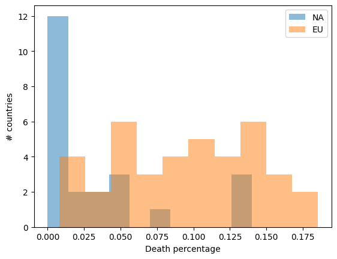

```python
plt.hist(deathNA, 10, alpha=0.5, label='NA')
plt.hist(deathEU, 10, alpha=0.5, label='EU')
plt.legend(loc='upper right')
plt.xlabel('Death percentage')
plt.ylabel('# countries')
plt.show()
```

```python
df.groupby('Continent').get_group('NA')
```

| Country | Alcoholic Beverages | Animal Products | Animal fats | Aquatic Products, Other | Cereals - Excluding Beer | Eggs | Fish, Seafood | Fruits - Excluding Wine | Meat | Miscellaneous | ... | Vegetables | Obesity | Undernourished | Confirmed | Deaths | Recovered | Active | Population | Unit (all except Population) | Continent |
| --- | --- | --- | --- | --- | --- | --- | --- | --- | --- | --- | --- | --- | --- | --- | --- | --- | --- | --- | --- | --- | --- |
| Antigua and Barbuda | 0.0 | 27.7033 | 4.6686 | 0.0000 | 3.2153 | 0.3872 | 1.5263 | 1.2177 | 14.3202 | 0.0898 | ... | 0.2469 | 19.1 | NaN | 0.293878 | 0.007143 | 0.190816 | 0.095918 | 98000.0 | % | NA |
| Bahamas | 0.0 | 30.2259 | 4.5600 | 0.0000 | 3.6327 | 1.2829 | 1.4991 | 0.8995 | 17.4941 | 0.3556 | ... | 0.3974 | 32.1 | NaN | 2.100763 | 0.044784 | 1.735115 | 0.320865 | 393000.0 | % | NA |
| Barbados | 0.0 | 25.8451 | 3.9733 | 0.0000 | 2.1187 | 1.2130 | 1.8060 | 0.4636 | 13.1382 | 0.3235 | ... | 0.2534 | 24.8 | 3.9 | 0.583972 | 0.006272 | 0.470035 | 0.107666 | 287000.0 | % | NA |
| Belize | 0.0 | 23.7877 | 9.8102 | 0.0000 | 3.0510 | 0.6759 | 0.4155 | 0.3039 | 10.3435 | 0.1984 | ... | 0.2108 | 22.4 | 7.5 | 2.872792 | 0.073031 | 2.739618 | 0.060143 | 419000.0 | % | NA |
| Canada | 0.0 | 23.1663 | 9.7895 | 0.0000 | 1.5440 | 1.2437 | 0.4244 | 0.4244 | 7.8211 | 0.0620 | ... | 0.2220 | 31.3 | <2.5 | 2.109961 | 0.054203 | 1.909848 | NaN | 38190000.0 | % | NA |
| Costa Rica | 0.0 | 20.5571 | 6.1000 | 0.0000 | 1.6733 | 1.1492 | 0.9286 | 0.5700 | 5.6449 | 0.0138 | ... | 0.1701 | 25.7 | 4.8 | 3.843436 | 0.052279 | 3.055782 | 0.735375 | 5111000.0 | % | NA |
| Cuba | 0.0 | 25.9025 | 3.2213 | 0.0000 | 4.4779 | 1.4788 | 0.2638 | 0.6179 | 16.0233 | 0.0139 | ... | 0.5554 | 26.7 | <2.5 | 0.283760 | 0.002065 | 0.230822 | 0.050873 | 11281000.0 | % | NA |
| Dominica | 0.0 | 26.9250 | 3.8063 | 0.0000 | 1.4913 | 0.3619 | 1.6536 | 1.1856 | 13.7339 | 0.1123 | ... | 0.2309 | 28.2 | 6.2 | 0.168056 | 0.000000 | 0.152778 | 0.015278 | 72000.0 | % | NA |
| Dominican Republic | 0.0 | 15.2779 | 2.2261 | 0.0000 | 1.4528 | 1.1248 | 0.2484 | 3.6133 | 7.3718 | 0.0422 | ... | 0.1218 | 26.9 | 9.5 | 2.115695 | 0.026676 | 1.577705 | 0.511314 | 10500000.0 | % | NA |
| El Salvador | 0.0 | 23.3032 | 6.3901 | 0.0000 | 8.1958 | 1.6034 | 0.4514 | 1.4321 | 6.6547 | 0.1012 | ... | 0.4514 | 22.7 | 9 | 0.867721 | 0.025814 | 0.778136 | 0.063771 | 6481000.0 | % | NA |
| Grenada | 0.0 | 23.0842 | 2.4889 | 0.0000 | 1.4883 | 1.4440 | 1.2856 | 2.8436 | 12.9576 | 0.1267 | ... | 0.1077 | 20.2 | NaN | 0.130973 | 0.000885 | 0.129204 | 0.000885 | 113000.0 | % | NA |
| Guatemala | 0.0 | 15.4397 | 1.7622 | 0.0000 | 9.3956 | 2.6186 | 0.1482 | 1.2516 | 7.0735 | 0.0247 | ... | 0.2553 | 18.8 | 15.2 | 0.901899 | 0.032403 | 0.824294 | 0.045201 | 18066000.0 | % | NA |
| Haiti | 0.0 | 12.1462 | 1.7481 | 0.0000 | 5.7517 | 0.1353 | 0.3722 | 1.6804 | 7.8944 | 0.0564 | ... | 0.1241 | 20.5 | 49.3 | 0.103113 | 0.002149 | 0.080295 | 0.020670 | 11403000.0 | % | NA |
| Honduras | 0.0 | 16.7113 | 2.6611 | 0.0000 | 8.3159 | 0.7448 | 0.1302 | 0.3760 | 7.8603 | 0.0651 | ... | 0.1157 | 19.4 | 12.9 | 1.560270 | 0.037612 | 0.626369 | 0.896290 | 9864000.0 | % | NA |
| Jamaica | 0.0 | 23.0867 | 6.1721 | 0.0064 | 2.2375 | 0.3242 | 1.2204 | 0.4322 | 9.5156 | 0.1081 | ... | 0.2924 | 24.4 | 8 | 0.599537 | 0.012709 | 0.435208 | 0.151620 | 2809000.0 | % | NA |
| Mexico | 0.0 | 23.7741 | 3.2525 | 0.0000 | 6.4604 | 2.2807 | 0.4661 | 0.5305 | 13.2133 | 0.0050 | ... | 0.2429 | 28.4 | 3.6 | 1.507199 | 0.129731 | 1.159805 | 0.217663 | 127792000.0 | % | NA |
| Nicaragua | 0.0 | 17.9935 | 2.3309 | 0.0000 | 9.2369 | 1.0080 | 0.4174 | 0.1339 | 7.6069 | 0.1102 | ... | 0.1811 | 21.8 | 17 | 0.095497 | 0.002577 | 0.064054 | 0.028866 | 6596000.0 | % | NA |
| Panama | 0.0 | 25.9557 | 9.1864 | 0.0000 | 3.8355 | 0.8991 | 0.8614 | 0.5722 | 9.1046 | 0.1320 | ... | 0.1258 | 22.5 | 10 | 7.622321 | 0.127364 | 6.773850 | 0.721107 | 4283000.0 | % | NA |
| Saint Kitts and Nevis | 0.0 | 24.3013 | 4.7370 | 0.0000 | 2.0602 | 0.5600 | 0.7296 | 0.3596 | 14.3547 | 0.1439 | ... | 0.1233 | 23.1 | NaN | 0.074074 | 0.000000 | 0.066667 | 0.007407 | 54000.0 | % | NA |
| Saint Lucia | 0.0 | 33.3454 | 3.8130 | 0.0000 | 1.6712 | 0.5249 | 1.5867 | 0.3741 | 22.8778 | 0.1629 | ... | 0.1508 | 19.8 | NaN | 0.996154 | 0.009890 | 0.480769 | 0.505495 | 182000.0 | % | NA |
| Saint Vincent and the Grenadines | 0.0 | 24.4653 | 1.0850 | 0.0000 | 4.3274 | 0.7589 | 0.7150 | 0.7526 | 17.5290 | 0.2258 | ... | 0.2509 | 23.8 | 5.7 | 1.082883 | 0.002703 | 0.361261 | 0.718919 | 111000.0 | % | NA |
| Trinidad and Tobago | 0.0 | 23.3455 | 5.3472 | 0.0000 | 2.5134 | 0.6185 | 0.7816 | 0.3205 | 11.3860 | 0.1012 | ... | 0.1799 | 19.7 | 5.5 | 0.556026 | 0.009861 | 0.529949 | 0.016216 | 1369000.0 | % | NA |
| United States of America | 0.0 | 21.2045 | 3.3013 | 0.0000 | 1.2829 | 1.2500 | 0.3887 | 0.4426 | 9.4166 | 0.0000 | ... | 0.1944 | 37.3 | <2.5 | 8.159922 | 0.140103 | 0.000000 | 8.019819 | 329878000.0 | % | NA |

23 rows × 32 columns

```python
df.groupby('Continent').get_group('EU')
```

| Country | Alcoholic Beverages | Animal Products | Animal fats | Aquatic Products, Other | Cereals - Excluding Beer | Eggs | Fish, Seafood | Fruits - Excluding Wine | Meat | Miscellaneous | ... | Vegetables | Obesity | Undernourished | Confirmed | Deaths | Recovered | Active | Population | Unit (all except Population) | Continent |
| --- | --- | --- | --- | --- | --- | --- | --- | --- | --- | --- | --- | --- | --- | --- | --- | --- | --- | --- | --- | --- | --- |
| Albania | 0.0 | 32.0002 | 3.4172 | 0.0 | 2.6734 | 1.6448 | 0.1445 | 0.6418 | 8.7428 | 0.0170 | ... | 0.6503 | 22.3 | 6.2 | 2.967301 | 0.050951 | 1.792636 | 1.123714 | 2838000.0 | % | EU |
| Austria | 0.0 | 27.8268 | 12.8517 | 0.0 | 1.2297 | 1.2147 | 0.4259 | 0.2249 | 8.1099 | 0.0000 | ... | 0.2039 | 21.9 | <2.5 | 4.739982 | 0.089679 | 4.496870 | 0.153433 | 8914000.0 | % | EU |
| Belarus | 0.0 | 23.8181 | 7.8662 | 0.0 | 4.8075 | 1.5772 | 0.5151 | 0.2316 | 11.5636 | 0.0519 | ... | 0.3394 | 26.6 | <2.5 | 2.740896 | 0.018912 | 2.612704 | 0.109280 | 9375000.0 | % | EU |
| Belgium | 0.0 | 26.7378 | 12.6234 | 0.0 | 1.3531 | 1.1703 | 0.6188 | 0.2373 | 5.6817 | 0.0000 | ... | 0.2982 | 24.5 | <2.5 | 6.286322 | 0.185428 | 0.000000 | 6.100894 | 11515000.0 | % | EU |
| Bosnia and Herzegovina | 0.0 | 24.6478 | 2.4453 | 0.0 | 3.6588 | 0.8354 | 0.3049 | 0.5976 | 9.6957 | 0.0915 | ... | 0.7866 | 19.4 | <2.5 | 3.762085 | 0.145535 | 2.960317 | 0.656233 | 3281000.0 | % | EU |
| Bulgaria | 0.0 | 27.1456 | 8.0274 | 0.0 | 1.8485 | 1.2201 | 0.3404 | 0.2723 | 9.3523 | 0.0262 | ... | 0.2461 | 27.4 | 3.6 | 3.227256 | 0.134416 | 2.788956 | 0.303883 | 6927000.0 | % | EU |
| Croatia | 0.0 | 29.3768 | 7.4457 | 0.0 | 2.9565 | 0.9476 | 0.5633 | 0.2577 | 11.4896 | 0.0000 | ... | 0.3930 | 27.1 | <2.5 | 5.848905 | 0.127960 | 5.648706 | 0.072239 | 4020000.0 | % | EU |
| Czechia | 0.0 | 25.1685 | 9.7011 | 0.0 | 1.1998 | 0.8222 | 0.3000 | 0.1870 | 8.6212 | 0.0212 | ... | 0.1729 | 28.5 | <2.5 | 9.612841 | 0.159845 | 8.555328 | 0.897667 | 10716000.0 | % | EU |
| Denmark | 0.0 | 35.4131 | 14.2498 | 0.0 | 1.4741 | 1.7484 | 1.1313 | 0.5257 | 9.2408 | 0.0000 | ... | 0.2819 | 21.3 | <2.5 | 3.463218 | 0.038017 | 3.307360 | 0.117842 | 5829000.0 | % | EU |
| Estonia | 0.0 | 33.2190 | 6.5339 | 0.0 | 2.8982 | 1.5830 | 0.2818 | 0.3805 | 10.4279 | 0.0188 | ... | 0.2865 | 23.8 | 2.9 | 3.569647 | 0.034260 | 2.828550 | 0.706837 | 1331000.0 | % | EU |
| Finland | 0.0 | 36.7250 | 6.3787 | 0.0 | 1.7872 | 0.8524 | 0.9384 | 0.2901 | 16.6649 | 0.1146 | ... | 0.2041 | 24.9 | <2.5 | 0.854802 | 0.012443 | 0.560680 | 0.281678 | 5529000.0 | % | EU |
| France | 0.0 | 30.2594 | 9.1996 | 0.0 | 1.4334 | 0.9894 | 0.8752 | 0.3869 | 11.0864 | 0.0159 | ... | 0.1776 | 23.2 | <2.5 | 5.199055 | 0.121558 | 0.367877 | 4.709620 | 64940000.0 | % | EU |
| Germany | 0.0 | 28.1419 | 11.0084 | 0.0 | 1.1778 | 1.0462 | 0.7019 | 0.2632 | 8.9127 | 0.0000 | ... | 0.2160 | 25.7 | <2.5 | 2.743101 | 0.073891 | 2.451366 | 0.217844 | 83300000.0 | % | EU |
| Greece | 0.0 | 17.9063 | 1.6989 | 0.0 | 1.3280 | 0.7749 | 0.3245 | 0.2484 | 6.6267 | 0.0298 | ... | 0.2848 | 27.4 | <2.5 | 1.525355 | 0.055617 | 0.876299 | 0.593439 | 10700000.0 | % | EU |
| Hungary | 0.0 | 28.9972 | 12.3082 | 0.0 | 1.2735 | 1.2018 | 0.1954 | 0.1270 | 10.0576 | 0.0000 | ... | 0.2019 | 28.6 | <2.5 | 3.840739 | 0.133367 | 2.845797 | 0.861575 | 9767000.0 | % | EU |
| Iceland | 0.0 | 34.4402 | 7.1086 | 0.0 | 4.3005 | 0.8991 | 1.6872 | 0.4975 | 13.6029 | 0.1199 | ... | 0.1678 | 23.1 | <2.5 | 1.636141 | 0.007880 | 1.619293 | 0.008967 | 368000.0 | % | EU |
| Ireland | 0.0 | 27.1689 | 8.6472 | 0.0 | 2.7091 | 0.9231 | 0.9372 | 0.2829 | 10.0477 | 0.0283 | ... | 0.2405 | 26.9 | <2.5 | 4.048531 | 0.073436 | 0.467000 | 3.508095 | 5003000.0 | % | EU |
| Italy | 0.0 | 21.8727 | 5.3931 | 0.0 | 1.3598 | 1.0529 | 0.7327 | 0.2541 | 8.7134 | 0.0198 | ... | 0.2277 | 22.9 | <2.5 | 4.353685 | 0.150927 | 3.494529 | 0.708229 | 60296000.0 | % | EU |
| Latvia | 0.0 | 30.4390 | 10.4430 | 0.0 | 1.5314 | 1.3430 | 0.8819 | 0.2526 | 9.7976 | 0.0361 | ... | 0.2606 | 25.7 | <2.5 | 3.749737 | 0.069769 | 3.122976 | 0.556993 | 1902000.0 | % | EU |
| Lithuania | 0.0 | 32.3048 | 9.3880 | 0.0 | 1.7819 | 1.9226 | 1.2380 | 0.3283 | 14.2134 | 0.0094 | ... | 0.2579 | 28.4 | <2.5 | 6.667072 | 0.104760 | 4.939621 | 1.622691 | 2794000.0 | % | EU |
| Luxembourg | 0.0 | 32.4517 | 6.4786 | 0.0 | 1.8437 | 1.6645 | 0.6987 | 0.3256 | 16.3118 | 0.0658 | ... | 0.2634 | 24.2 | <2.5 | 8.150633 | 0.093354 | 7.661551 | 0.395728 | 632000.0 | % | EU |
| Malta | 0.0 | 29.3856 | 6.6557 | 0.0 | 4.8786 | 1.3878 | 1.3074 | 0.2666 | 10.6541 | 0.0169 | ... | 0.5162 | 31.0 | <2.5 | 3.558621 | 0.053448 | 3.045211 | 0.459962 | 522000.0 | % | EU |
| Montenegro | 0.0 | 32.7855 | 3.8887 | 0.0 | 3.7312 | 1.1566 | 0.3473 | 0.3688 | 14.7778 | 0.1003 | ... | 0.2578 | 24.9 | <2.5 | 10.408199 | 0.134405 | 9.039871 | 1.233923 | 622000.0 | % | EU |
| Netherlands | 0.0 | 30.1494 | 6.6484 | 0.0 | 1.2702 | 1.4787 | 0.7451 | 0.3475 | 10.8567 | 0.0000 | ... | 0.2355 | 23.1 | <2.5 | 5.815292 | 0.082830 | 0.076063 | 5.656398 | 17467000.0 | % | EU |
| North Macedonia | 0.0 | 19.6420 | 7.1263 | 0.0 | 1.9013 | 0.7305 | 0.2371 | 0.4112 | 6.5409 | 0.0435 | ... | 0.7450 | 23.9 | 3.2 | 4.548029 | 0.140192 | 4.025721 | 0.382115 | 2080000.0 | % | EU |
| Norway | 0.0 | 27.2211 | 6.4445 | 0.0 | 1.9601 | 1.0645 | 1.5545 | 0.4055 | 10.6992 | 0.3244 | ... | 0.1656 | 25.0 | <2.5 | 1.200167 | 0.010804 | 0.334101 | 0.855263 | 5387000.0 | % | EU |
| Poland | 0.0 | 32.7460 | 12.3719 | 0.0 | 1.6183 | 0.7141 | 0.4851 | 0.2057 | 13.3072 | 0.0000 | ... | 0.2639 | 25.6 | <2.5 | 4.028175 | 0.101632 | 3.392335 | 0.534208 | 38368000.0 | % | EU |
| Portugal | 0.0 | 26.4556 | 9.5983 | 0.0 | 2.1808 | 0.7993 | 1.0267 | 0.2825 | 10.3459 | 0.0138 | ... | 0.2825 | 23.2 | <2.5 | 7.429605 | 0.136070 | 5.846836 | 1.446699 | 10255000.0 | % | EU |
| Republic of Moldova | 0.0 | 26.5244 | 6.8551 | 0.0 | 2.5570 | 1.5517 | 0.6921 | 0.2987 | 9.7764 | 0.0656 | ... | 0.3570 | 20.1 | NaN | 4.646195 | 0.099859 | 4.333692 | 0.212645 | 3535000.0 | % | EU |
| Romania | 0.0 | 27.4359 | 6.8987 | 0.0 | 2.5519 | 1.5914 | 0.1994 | 0.2930 | 7.9894 | 0.0366 | ... | 0.4477 | 24.5 | <2.5 | 3.863328 | 0.097755 | 3.583358 | 0.182215 | 19241000.0 | % | EU |
| Russian Federation | 0.0 | 27.9360 | 7.2000 | 0.0 | 1.6511 | 1.9603 | 0.9415 | 0.2138 | 10.8433 | 0.0091 | ... | 0.2638 | 25.7 | <2.5 | 2.663104 | 0.051120 | 2.316142 | 0.295842 | 146733000.0 | % | EU |
| Serbia | 0.0 | 33.0354 | 4.0698 | 0.0 | 2.1213 | 1.5195 | 0.3396 | 0.5780 | 18.1385 | 0.0060 | ... | 0.3635 | 23.5 | 5.7 | 5.840908 | 0.059106 | 0.000000 | 5.781803 | 6957000.0 | % | EU |
| Slovakia | 0.0 | 25.4930 | 14.9373 | 0.0 | 2.0003 | 1.1183 | 0.2331 | 0.1386 | 5.8496 | 0.0095 | ... | 0.1292 | 22.4 | 3.4 | 4.792640 | 0.094013 | 4.361424 | 0.337202 | 5462000.0 | % | EU |
| Slovenia | 0.0 | 26.6163 | 10.0008 | 0.0 | 3.5771 | 1.1287 | 0.3693 | 0.4606 | 8.5899 | 0.0622 | ... | 0.2697 | 22.5 | <2.5 | 8.235901 | 0.171755 | 7.312934 | 0.751213 | 2103000.0 | % | EU |
| Spain | 0.0 | 19.5253 | 2.4641 | 0.0 | 1.0780 | 1.2521 | 1.0814 | 0.3750 | 9.2772 | 0.0000 | ... | 0.2611 | 27.1 | <2.5 | 6.176110 | 0.128867 | 0.315684 | 5.731559 | 47635000.0 | % | EU |
| Sweden | 0.0 | 28.4111 | 9.7148 | 0.0 | 1.9481 | 1.3741 | 0.8778 | 0.3556 | 8.8481 | 0.0481 | ... | 0.2296 | 22.1 | <2.5 | 5.666975 | 0.116749 | 0.000000 | 5.550226 | 10377000.0 | % | EU |
| Switzerland | 0.0 | 28.1054 | 6.2293 | 0.0 | 1.1241 | 0.9300 | 0.4048 | 0.3379 | 12.0906 | 0.0000 | ... | 0.2141 | 21.2 | <2.5 | 6.160215 | 0.111258 | 3.678480 | 2.370477 | 8634000.0 | % | EU |
| Ukraine | 0.0 | 26.9100 | 5.4940 | 0.0 | 3.0837 | 2.4481 | 0.5160 | 0.3084 | 9.6350 | 0.0063 | ... | 0.5223 | 26.1 | 3.5 | 3.075923 | 0.059206 | 2.653382 | 0.363335 | 41778000.0 | % | EU |
| United Kingdom | 0.0 | 25.8633 | 4.2615 | 0.0 | 1.4678 | 1.0778 | 0.5176 | 0.4219 | 12.5789 | 0.0780 | ... | 0.2127 | 29.5 | <2.5 | 5.868483 | 0.167220 | 0.015161 | 5.686102 | 67160000.0 | % | EU |

39 rows × 32 columns